# R Notebook

Name: Mayuri Patel

Email: mpate131@uncc.edu

title: “Lab4_AdvStats”

(1A) Plot the prior graph for a situation for a coin where the prior belief for p(head) is represented by the following R code :

```
    dexp(x, rate =5) / 0.9932621

for values of 0 <= x <= 1 and 0 otherwise.  (We choose the denominator to make the Integral between 0 and 1 sum to 1).
```

```r
#Taking the seq from 0 to 1
x <- seq(0,1,0.01)

#The value for this exp R code is below:
dexp(x, rate =5) / 0.9932621
```

```
##   [1] 5.03391804 4.78841096 4.55487740 4.33273341 4.12142350 3.92041931
##   [7] 3.72921820 3.54734208 3.37433617 3.20976785 3.05322563 2.90431806
##  [13] 2.76267279 2.62793565 2.49976972 2.37785451 2.26188518 2.15157173
##  [19] 2.04663834 1.94682261 1.85187495 1.76155795 1.67564575 1.59392354
##  [25] 1.51618698 1.44224166 1.37190271 1.30499422 1.24134890 1.18080760
##  [31] 1.12321894 1.06843890 1.01633052 0.96676350 0.91961389 0.87476379
##  [37] 0.83210105 0.79151901 0.75291617 0.71619602 0.68126672 0.64804095
##  [43] 0.61643562 0.58637170 0.55777402 0.53057106 0.50469480 0.48008055
##  [49] 0.45666674 0.43439484 0.41320916 0.39305671 0.37388710 0.35565242
##  [55] 0.33830704 0.32180761 0.30611287 0.29118357 0.27698238 0.26347379
##  [61] 0.25062402 0.23840094 0.22677399 0.21571409 0.20519359 0.19518618
##  [67] 0.18566684 0.17661176 0.16799831 0.15980493 0.15201115 0.14459748
##  [73] 0.13754538 0.13083721 0.12445621 0.11838641 0.11261263 0.10712045
##  [79] 0.10189612 0.09692659 0.09219942 0.08770281 0.08342549 0.07935678
##  [85] 0.07548650 0.07180498 0.06830301 0.06497184 0.06180312 0.05878895
##  [91] 0.05592178 0.05319444 0.05060012 0.04813232 0.04578488 0.04355192
##  [97] 0.04142787 0.03940741 0.03748549 0.03565730 0.03391827
```

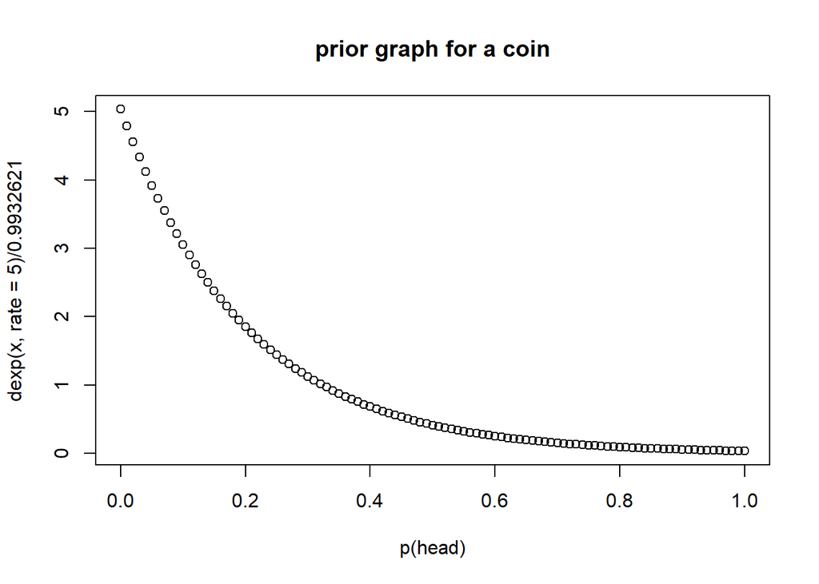

```r
#plotting those values with dexp.
plot(x, dexp(x, rate =5) / 0.9932621,main="prior graph for a coin", xlab="p(head)" )
```

(1B) Calculate the posterior graph with both the Metropolis algorithm and grid approximation for a case with 14 heads and 10 tails (where x = prob(head)) . Show the two methods roughly agree. Compare these to a plot with a posterior for new data of 14 heads and 10 tails with a prior with beta(40,40).

(So for the observation of 14 heads and 10 tails you will end up with a graph with three plots superimposed: (i) the Metropolis algorithm with an exp prior, (ii) grid approximation with an exp prior and (iii) exact analytical solution from a beta(40,40) prior make the plots different colors so you can visualize them…)

- Metropolis algorithm:

```r
#piold value is set as 0.5
piOld <- 0.5

#taking number of iterations for this algorithm to run
numIterations <- 500000
#empty variable to save the values of posteriors
posteriorDist <- vector()

#for loop the iteration
for( i in 1:numIterations )
{
    # our prior with 39 heads and 39 tails
    # our new data with 14 heads and 10 tails
  #we are usinf dexp here for prior
    pOld <- dexp(x, rate =5) / 0.9932621  * dbinom( 14, 24, piOld )

    piNew <- piOld + rnorm(1, 0, sd =0.01); #selecting the standard deviation
    #Checking for the pi new values
    if( piNew > 1)
        piNew = 1;

    if( piNew < 0 )
        piNew =0;

    pNew <- dexp(x, rate =5) / 0.9932621 * dbinom( 14, 24, piNew )
    #calculating the ratio
    ratio <- pNew / pOld

    if( ratio > 1 || ratio >= runif(1) )
        piOld = piNew;

    #storing the pi old values in posterior
    posteriorDist[i] = piOld;

}
myHist <- hist(posteriorDist,breaks=200, plot=FALSE)
```

- Grid approximation:

```r
#taking number of breaks
numBreaks=200;
posteriorDist_grid <- vector(length=numBreaks) # setting an empty variable to store posterior values
xVals <- seq(0,1,1/numBreaks);

#setting the sum to 0
i <- 1;
sum <- 0;

for( x in xVals )
{
    # our prior with 39 heads and 39 tails
    # our new data with 14 heads and 10 tails
  #we are using prior as dexp
    posteriorDist_grid[i] <- dexp(x, rate =5) / 0.9932621 * dbinom( 14, 24, x)
    sum = sum + posteriorDist_grid[i]; # sum the values of posteriors
    i <- i + 1;
}
```

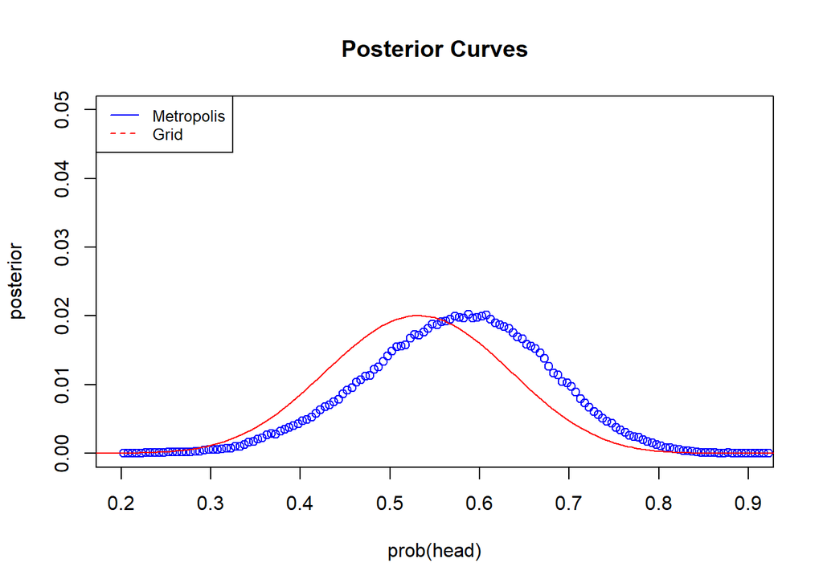

```r
plot( myHist$mids, myHist$counts/length(posteriorDist),xlim =c(0.2,0.9),ylim=c(0,0.05),col='blue',main= "Posterior Curves", xlab="prob(head)", ylab="posterior") #the midpoints of cells #the number
lines(xVals,posteriorDist_grid/sum,col="red",xlim =c(0.2,0.9),ylim=c(0,0.05))
legend("topleft", legend=c("Metropolis", "Grid"),col=c("blue", "red"), lty=1:2, cex=0.8)
```

- Exact analytical solution from a beta(40,40) prior:

```r
#taking number of breaks
numBreaks1=200;
post_Dist <- vector(length=numBreaks) # setting an empty variable to store posterior values
xValues <- seq(0,1,1/numBreaks1);

i <- 1;
sum1 <- 0; #setting the sum to 0

for( x in xValues )
{
    # our prior with 39 heads and 39 tails
    # our new data with 14 heads and 10 tails
  #we are using the dbeta for exact analytical solution for prior
    post_Dist[i] <- dbeta( x, 40,40 ) * dbinom( 14, 24, x)
    sum1 = sum1 + post_Dist[i]; # sum the values of posteriors
    i <- i + 1;
}
```

- The observation of 14 heads and 10 tails end up with a graph with three plots superimposed:

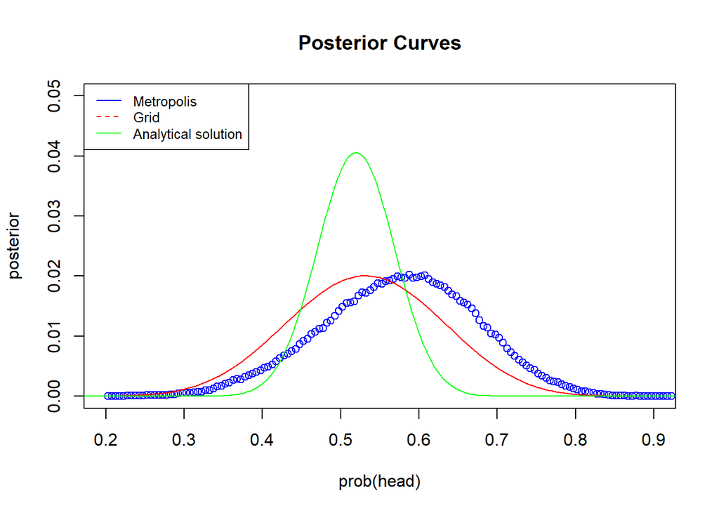

```r
plot( myHist$mids, myHist$counts/length(posteriorDist),xlim =c(0.2,0.9),ylim=c(0,0.05),col='blue',main= "Posterior Curves", xlab="prob(head)", ylab="posterior") #the midpoints of cells #the number
lines(xVals,posteriorDist_grid/sum,col="red",xlim =c(0.2,0.9),ylim=c(0,0.05))
lines(xValues,post_Dist/sum1, col="green", xlim =c(0.2,0.9),ylim=c(0,0.05))
legend("topleft", legend=c("Metropolis", "Grid","Analytical solution"),col=c("blue", "red","green"), lty=1:2, cex=0.8)
```

(1C) Repeat the above calculation but for a case of 583 heads and 417 tails. (You may need to adjust your model step parameters to try and get the grid and Metropolis graphs to match up). How do the three posterior curves relate to each other now? Why does this plot look different than the plot in (1B)?

- Metropolis algorithm:

```r
#set the pi old to 0.5
piOld <- 0.5

#setting the iteration
numIterations <- 500000

#empty variable to save the values of posteriors
posteriorDist1 <- vector()

#for loop the iteration
for( i in 1:numIterations )
{
    # our prior with 39 heads and 39 tails
    # our new data with 583 heads and 417 tails
  #we use dexp for prior
    pOld <- dexp(x, rate =5) / 0.9932621 * dbinom(583,1000, piOld )

    piNew <- piOld + rnorm(1, 0, sd =0.01);#selecting the standard deviation
    #Checking for the pi new values
    if( piNew > 1)
        piNew = 1;

    if( piNew < 0 )
        piNew =0;

    pNew <- dexp(x, rate =5) / 0.9932621 * dbinom(583,1000, piNew )
    #calculating the ratio
    ratio <- pNew / pOld

    if( ratio > 1 || ratio >= runif(1) )
        piOld = piNew;

    #storing the pi old values in posterior
    posteriorDist1[i] = piOld;

}
myHist <- hist(posteriorDist1,breaks=200, plot=FALSE)
```

- Grid approximation:

```r
#taking number of breaks
numBreaks=900;
posteriorDist_grid1 <- vector(length=numBreaks)# setting an empty variable to store posterior values
xVals <- seq(0,1,1/numBreaks);

#setting the sum to 0
i <- 1;
Sum <- 0;

for( x in xVals )
{
    # our prior with 39 heads and 39 tails
    # our new data with 583 heads and 417 tails
    posteriorDist_grid1[i] <- dexp(x, rate =5) / 0.9932621 * dbinom(583,1000, x)
    Sum = Sum + posteriorDist_grid1[i]; # sum the values of posteriors
    i <- i + 1;
}
```

- Exact analytical solution from a beta(40,40) prior:

```r
#taking number of breaks
numBreaks1=900;
post_Dist1 <- vector(length=numBreaks) # setting an empty variable to store posterior values
xValues <- seq(0,1,1/numBreaks1);

i <- 1;
Sum1 <- 0; #setting the sum to 0

for( x in xValues )
{
    # our prior with 39 heads and 39 tails
    # our new data with 583 heads and 417 tails
  #we are using the dbeta for exact analytical solution for prior
    post_Dist1[i] <- dbeta( x, 40,40 ) * dbinom(583,1000, x)
    Sum1 = Sum1 + post_Dist1[i]; # sum the values of posteriors
    i <- i + 1;
}
```

- The observation of 583 heads and 417 tails end up with a graph with three plots superimposed:

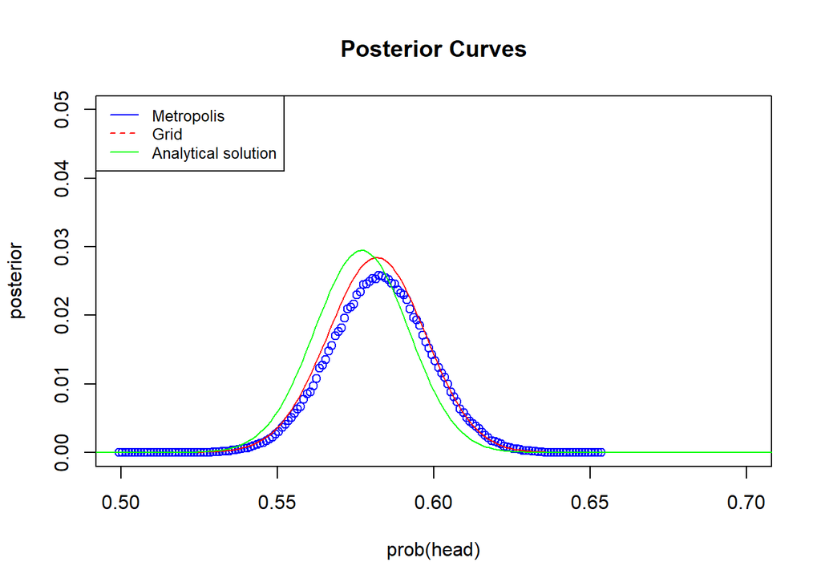

```r
plot( myHist$mids, myHist$counts/length(posteriorDist1),xlim =c(0.5,0.7),ylim=c(0,0.05),col='blue',main= "Posterior Curves", xlab="prob(head)", ylab="posterior") #the midpoints of cells #the number
lines(xVals,posteriorDist_grid1/Sum,col="red",xlim =c(0.5,0.7),ylim=c(0,0.05))
lines(xValues,post_Dist1/Sum1, col="green", xlim =c(0.5,0.7),ylim=c(0,0.05))
legend("topleft", legend=c("Metropolis", "Grid","Analytical solution"),col=c("blue", "red","green"), lty=1:2, cex=0.8)
```